# Exam 1

## Exam 1

#### Question

1. En un museo, el presupuesto total disponible para entretenimiento es de $96000$. Este presupuesto se distribuye entre el costo de boleto y el costo de souvenir, de tal manera que cuando aumenta el gasto en uno, disminuye proporcionalmente el gasto en el otro.

   La siguiente tabla muestra la relacion entre estas dos variables:

   | **Costo de boleto (x)** | **Costo de souvenir (y)** |
   | --- | --- |
   | 0 | 96000 |
   | 10000 | 86000 |
   | 19000 | 77000 |
   | 29000 | 67000 |
   | 38000 | 58000 |
   | 48000 | 48000 |
   | 58000 | 38000 |
   | 67000 | 29000 |

   La grafica que representa esta funcion es:

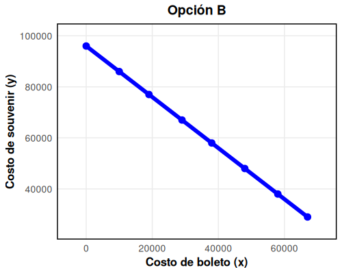

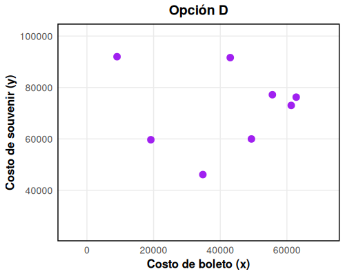

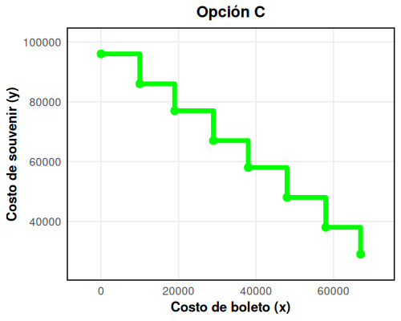

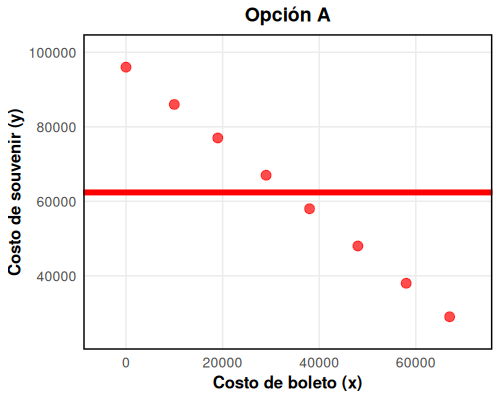

#### Solution

   Para resolver este problema, debemos analizar la relacion entre las dos variables presentadas en la tabla.

   Observando los datos: - Cuando el boleto cuesta $0$, el souvenir cuesta $96000$ - Cuando el boleto cuesta $67000$, el souvenir cuesta $29000$

   Esto muestra una relacion lineal decreciente: a medida que aumenta el costo de boleto, disminuye el costo de souvenir, manteniendo un presupuesto total constante de $96000$.
   1. Verdadero. La grafica B representa correctamente la relacion lineal decreciente: a mayor costo de uno, menor costo del otro.
   2. Falso. La grafica D muestra puntos dispersos sin conexion, no una funcion matematica definida.
   3. Falso. La grafica C muestra una funcion escalonada, no una relacion continua como la del presupuesto fijo.
   4. Falso. La grafica A muestra una relacion constante, no la relacion inversa esperada entre los costos.